# Cyclistic Bike Company

Pratibha

12/17/2021

# Cyclistic Bike-Share Case Study

## Business Task

Cyclistic is a bicycle share company operating in Chicago. It has two types of membership: casual and members. Members are people who have annual membership with the company and use cycles regularly as a means of transport The director of marketing believes the company’s future success depends on maximizing the number of annual memberships. Therefore, your team wants to understand how casual riders and annual members use Cyclistic bikes differently. From these insights, your team will design a new marketing strategy to convert casual riders into annual members.

## Shareholders

- Lily Moreno: The director of marketing. She is responsible for the development of campaigns and initiatives to promote the bike-share program
- Cyclistic Company
- Cyclistic marketing analytics team: A team of data analysts who are responsible for collecting, analyzing, and reporting data that helps guide Cyclistic marketing strategy.
- Cyclistic executive team: The detail-oriented executive team will decide whether to approve the recommended marketing program

# Phases of Data Analysis

## Ask:

The question you need to ask to understand the goal. Three questions will guide the future marketing program: + How do annual members and casual riders use Cyclistic bikes differently? + Why would casual riders buy Cyclistic annual memberships? + How can Cyclistic use digital media to influence casual riders to become members

## Prepare and Process:

The data is in a public database. The data has been made available by Motivate International Inc. The data is organized month wise starting from April 2020. It has 13 columns :ride_id, rideable_type,started_at,ended_at, start_station_name, start_station_id, end_station_name, end_station_id, start_lat, start_lng, end_lat, end_lng, member_casual

### install and load libraries for data wrangling and visualization

[output not shown]

[output not shown]

[output not shown]

[output not shown]

### Import 12 csv files from May 2020 till April 2021

By checking structure of all the files it is clear that start_station_id and end_station_id columns were integer datatype for 2020 except for December month and Character data type for 2021.We will have to change the data type of four files in 2021 to integer so that we bind all the csv files into one data frame

### Cleaning The Data

Find duplicate entries

```
## # A tibble: 789 x 2
##    ride_id          num_duplicates
##    <chr>                     <int>
##  1 021A73F8C18B932D              2
##  2 0334987B57662109              2
##  3 038CAB4A84D9A56B              2
##  4 0425DA22910BD202              2
##  5 05498BABECEB55B0              2
##  6 06AD9EC9352D7A00              2
##  7 0852F31B41CB650D              2
##  8 0A2B0949201A9D0C              2
##  9 0A4365A64FF49318              2
## 10 0C3CB45FD307654C              2
## # ... with 779 more rows
```

There are 789 duplicate values Remove the duplicates

```r
cycle_trips_final <- cycle_trips[!duplicated(cycle_trips$ride_id),]
```

### First 6 rows of the data frame

```
##            ride_id rideable_type      started_at        ended_at
## 1 02668AD35674B983   docked_bike 5/27/2020 10:03 5/27/2020 10:16
## 2 7A50CCAF1EDDB28F   docked_bike 5/25/2020 10:47 5/25/2020 11:05
## 3 2FFCDFDB91FE9A52   docked_bike  5/2/2020 14:11  5/2/2020 15:48
## 4 58991CF1DB75BA84   docked_bike  5/2/2020 16:25  5/2/2020 16:39
## 5 A79651EFECC268CD   docked_bike 5/29/2020 12:49 5/29/2020 13:27
## 6 1466C5B39F68F746   docked_bike 5/29/2020 13:27 5/29/2020 14:14
##           start_station_name start_station_id               end_station_name
## 1 Franklin St & Jackson Blvd               36         Wabash Ave & Grand Ave
## 2  Clark St & Wrightwood Ave              340          Clark St & Leland Ave
## 3 Kedzie Ave & Milwaukee Ave              260     Kedzie Ave & Milwaukee Ave
## 4 Clarendon Ave & Leland Ave              251 Lake Shore Dr & Wellington Ave
## 5    Hermitage Ave & Polk St              261        Halsted St & Archer Ave
## 6    Halsted St & Archer Ave              206             May St & Taylor St
##   end_station_id start_lat start_lng end_lat  end_lng member_casual
## 1            199   41.8777  -87.6353 41.8915 -87.6268        member
## 2            326   41.9295  -87.6431 41.9671 -87.6674        casual
## 3            260   41.9296  -87.7079 41.9296 -87.7079        casual
## 4            157   41.9680  -87.6500 41.9367 -87.6368        casual
## 5            206   41.8715  -87.6699 41.8472 -87.6468        member
## 6             22   41.8472  -87.6468 41.8695 -87.6555        member
```

### Summary of the data frame

```
##    ride_id          rideable_type       started_at          ended_at
##  Length:3740899     Length:3740899     Length:3740899     Length:3740899
##  Class :character   Class :character   Class :character   Class :character
##  Mode  :character   Mode  :character   Mode  :character   Mode  :character
##
##
##
##
##  start_station_name start_station_id end_station_name   end_station_id
##  Length:3740899     Min.   :     2   Length:3740899     Min.   :     2
##  Class :character   1st Qu.:   112   Class :character   1st Qu.:   112
##  Mode  :character   Median :   226   Mode  :character   Median :   226
##                     Mean   :  1536                      Mean   :  1536
##                     3rd Qu.:   349                      3rd Qu.:   349
##                     Max.   :202480                      Max.   :202480
##                     NA's   :587916                      NA's   :604474
##    start_lat       start_lng         end_lat         end_lng
##  Min.   :41.64   Min.   :-87.87   Min.   :41.54   Min.   :-88.07
##  1st Qu.:41.88   1st Qu.:-87.66   1st Qu.:41.88   1st Qu.:-87.66
##  Median :41.90   Median :-87.64   Median :41.90   Median :-87.64
##  Mean   :41.90   Mean   :-87.64   Mean   :41.90   Mean   :-87.64
##  3rd Qu.:41.93   3rd Qu.:-87.63   3rd Qu.:41.93   3rd Qu.:-87.63
##  Max.   :42.08   Max.   :-87.52   Max.   :42.16   Max.   :-87.44
##                                   NA's   :4902    NA's   :4902
##  member_casual
##  Length:3740899
##  Class :character
##  Mode  :character
##
##
##
##
```

### Final Data Frame after Data Wrangling

```
##            ride_id rideable_type          started_at            ended_at
## 1 02668AD35674B983   docked_bike 2020-05-27 10:03:00 2020-05-27 10:16:00
## 2 7A50CCAF1EDDB28F   docked_bike 2020-05-25 10:47:00 2020-05-25 11:05:00
## 3 2FFCDFDB91FE9A52   docked_bike 2020-05-02 14:11:00 2020-05-02 15:48:00
## 4 58991CF1DB75BA84   docked_bike 2020-05-02 16:25:00 2020-05-02 16:39:00
## 5 A79651EFECC268CD   docked_bike 2020-05-29 12:49:00 2020-05-29 13:27:00
## 6 1466C5B39F68F746   docked_bike 2020-05-29 13:27:00 2020-05-29 14:14:00
##           start_station_name start_station_id               end_station_name
## 1 Franklin St & Jackson Blvd               36         Wabash Ave & Grand Ave
## 2  Clark St & Wrightwood Ave              340          Clark St & Leland Ave
## 3 Kedzie Ave & Milwaukee Ave              260     Kedzie Ave & Milwaukee Ave
## 4 Clarendon Ave & Leland Ave              251 Lake Shore Dr & Wellington Ave
## 5    Hermitage Ave & Polk St              261        Halsted St & Archer Ave
## 6    Halsted St & Archer Ave              206             May St & Taylor St
##   end_station_id start_lat start_lng end_lat  end_lng member_casual       date
## 1            199   41.8777  -87.6353 41.8915 -87.6268        member 2020-05-27
## 2            326   41.9295  -87.6431 41.9671 -87.6674        casual 2020-05-25
## 3            260   41.9296  -87.7079 41.9296 -87.7079        casual 2020-05-02
## 4            157   41.9680  -87.6500 41.9367 -87.6368        casual 2020-05-02
## 5            206   41.8715  -87.6699 41.8472 -87.6468        member 2020-05-29
## 6             22   41.8472  -87.6468 41.8695 -87.6555        member 2020-05-29
##   month day year day_of_week ride_length month_name
## 1    05  27 2020   Wednesday    780 secs        May
## 2    05  25 2020      Monday   1080 secs        May
## 3    05  02 2020    Saturday   5820 secs        May
## 4    05  02 2020    Saturday    840 secs        May
## 5    05  29 2020      Friday   2280 secs        May
## 6    05  29 2020      Friday   2820 secs        May
```

## Visualization and Analysis

### Day Wise number of Rides Average Time Spent By Members and Casual Riders

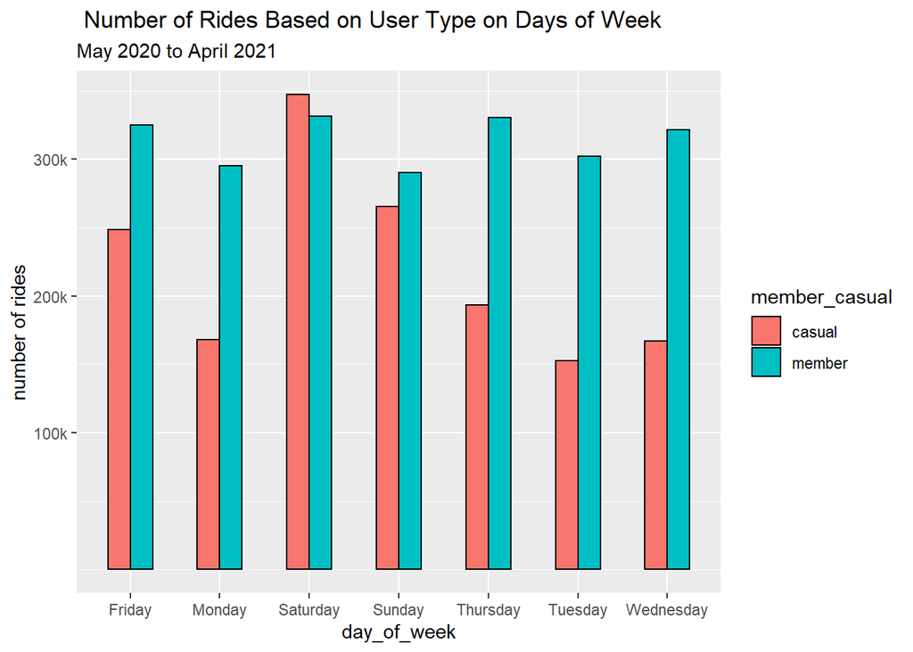

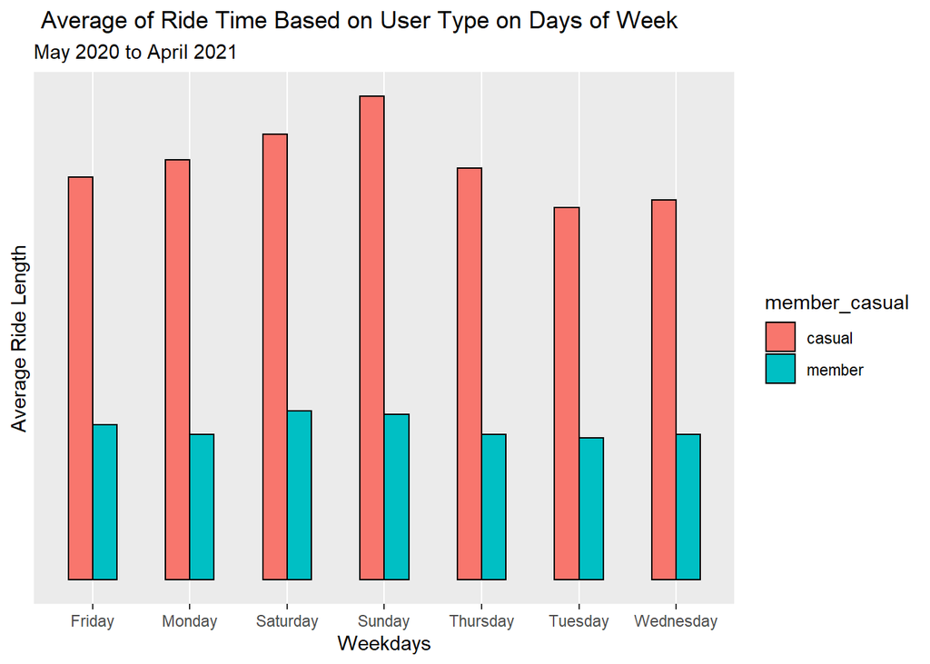

### Average Ride Length and Number of Rides Based on User Types

### Graphical Representation of Mean of number of rides for both member and casual

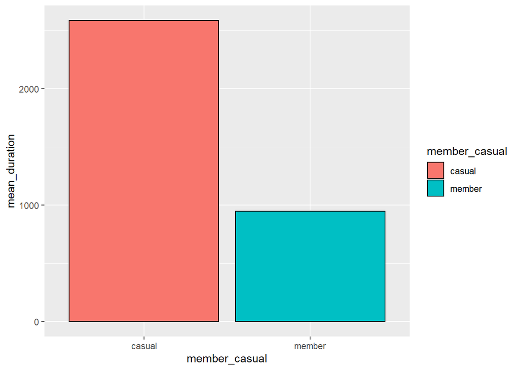

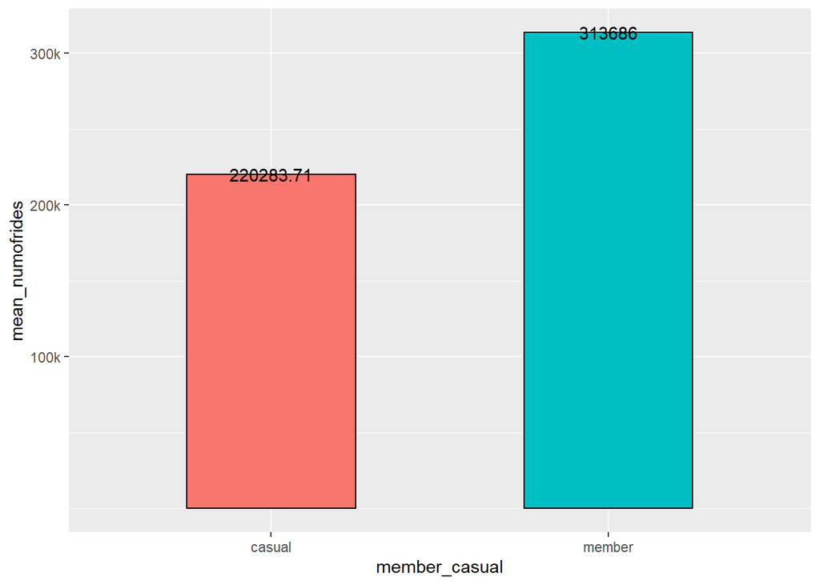

### Cycle Usage Based On Bike Type And Member Type

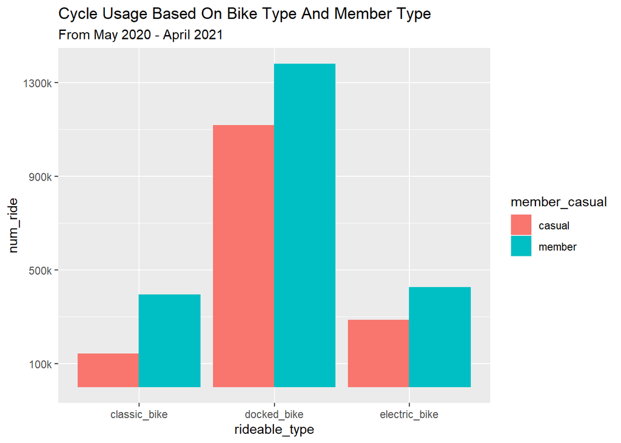

### Average ride time and number of rides based on month and User Type

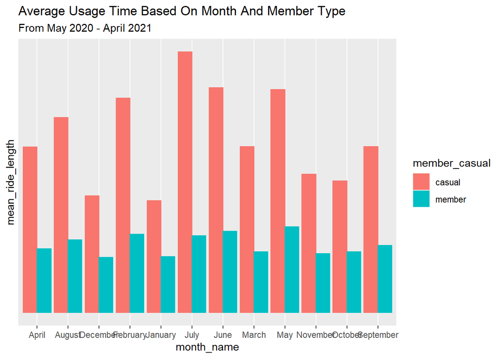

```
## # A tibble: 24 x 3
## # Groups:   member_casual [2]
##    member_casual month_name num_ride_month
##    <chr>         <chr>               <int>
##  1 casual        April              136547
##  2 casual        August             289364
##  3 casual        December            29987
##  4 casual        February            10124
##  5 casual        January             18112
##  6 casual        July               269124
##  7 casual        June               154677
##  8 casual        March               83997
##  9 casual        May                 86898
## 10 casual        November            88000
## # ... with 14 more rows
```

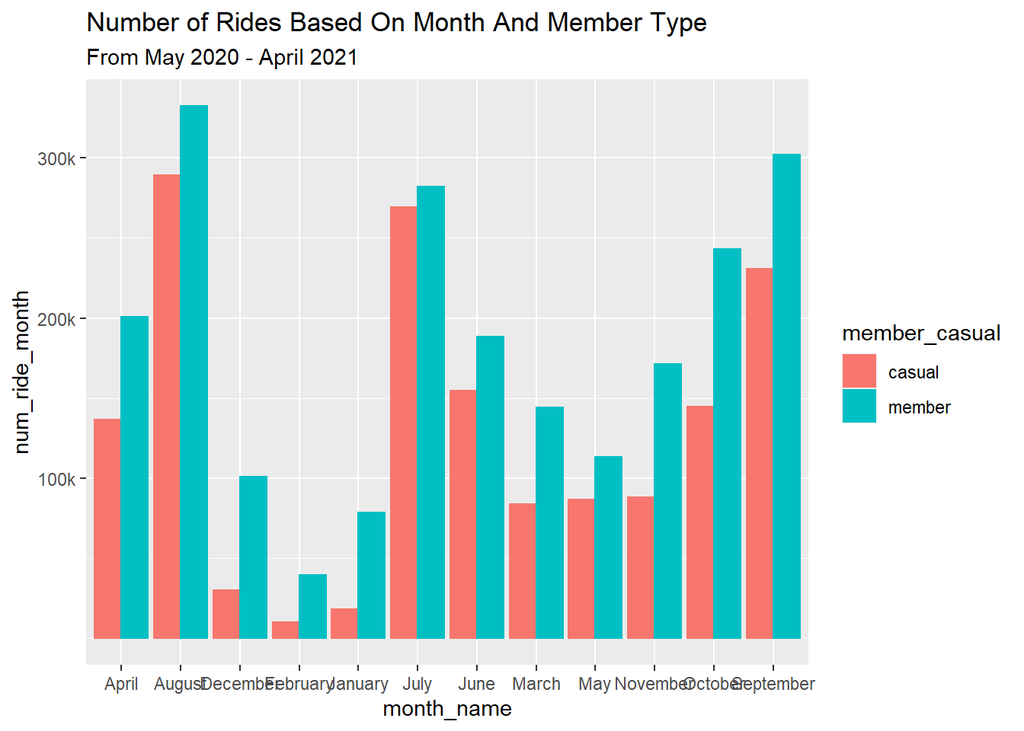